# Storm Damage Events from 1997 to 2011

Evaluation of Highest Injury, Fatality and Economic Events

Mark Brantana

11/9/2020

## SYNOPSIS

This study is to evaluate the weather events having the greatest impact upon induries, fatalities and economics. Storms and other severe weather events can cause both public health and economic problems for communities and municipalities. Many severe events can result in fatalities, injuries, and property damage, and preventing such outcomes to the extent possible is a key concern.

Data from the U.S. National Oceanic and Atmospheric Administration’s (NOAA) storm database is analyzed to estimate these effects in the US over a period from 1997 to 2011. This database tracks characteristics of major storms and weather events in the United States, including when and where they occur, as well as estimates of any fatalities, injuries, and property damage.

## DATA PROCESSING

The events in the database start in the year 1950 and end in November 2011. In the earlier years of the database there are generally fewer events recorded, most likely due to a lack of good records. More recent years should be considered more complete. The study ignores data before 1997 in light of the earlier dearth of data. Additionally, data is better defined in these more recent years. Data is downloaded, selected and cleaned to arrive at what is felt to be a representive population data set.

### r PACKAGES LOADED

```r
library(knitr)
library(dplyr)
library(lubridate)
library(ggplot2)
library(lattice)
library(R.utils)
```

### READING IN THE DATA

```r
# DOWNLOAD DATA FROM SOURCE AND CONVERT TO DATAFRAME.
# Download zip datafile from cloudfront
source_url = "https://d396qusza40orc.cloudfront.net/repdata%2Fdata%2FStormData.csv.bz2"
datasource_zip="/Users/Brantana-Air/Desktop/Data_Projects/Coursera/Johns_Hopkins/Reproducible_Research/Course_Project_2/storms.zip"
download.file(source_url,destfile=datasource_zip)
# Unzip datafile
bunzip2(datasource_zip, "storms.csv", remove = FALSE, skip = TRUE)
```

```
## [1] "storms.csv"
## attr(,"temporary")
## [1] FALSE
```

```r
# Convert csv file to dataframe
datasource_csv="/Users/Brantana-Air/Desktop/Data_Projects/Coursera/Johns_Hopkins/Reproducible_Research/Course_Project_2/storms.csv"
df0 <- as.data.frame(read.csv(file=datasource_csv, header=TRUE, sep=",",stringsAsFactors = FALSE))
```

### DATA PROCESSING

```r
# Select only more recent and accurate dates
df0$BGN_DATE<-mdy_hms(df0$BGN_DATE)
df0<-df0 %>% filter(year(BGN_DATE)>1996)
# DATA ANALYSIS
# 1. Across the United States, which types of events (as indicated in the EVTYPE variable)
# are most harmful with respect to population health?
# Number of buckets to plot, N
N = 25
# Produce dataframe for Injuries
df1 <- df0 %>%
        group_by(EVTYPE) %>%
        summarise(Sum_Injuries = sum(INJURIES))
df1 <- df1[order(df1$Sum_Injuries, decreasing=TRUE), ]
df1$cumulative <- cumsum(df1$Sum_Injuries)
s1 = sum(df1$Sum_Injuries)
df1 <- df1[0:N,]
df1$EVTYPE <- factor(df1$EVTYPE, levels = df1$EVTYPE[order(df1$cumulative)])
# Produce dataframe for Fatalities
df2 <- df0 %>%
        group_by(EVTYPE) %>%
        summarise(Sum_Fatalities = sum(FATALITIES))
df2 <- df2[order(df2$Sum_Fatalities, decreasing=TRUE), ]
df2$cumulative <- cumsum(df2$Sum_Fatalities)
s2 = sum(df2$Sum_Fatalities)
df2 <- df2[0:N,]
df2$EVTYPE <- factor(df2$EVTYPE, levels = df2$EVTYPE[order(df2$cumulative)])
# 2. Across the United States, which types of events have the greatest economic consequences?
# Convert property damage exponent symbols to numeric orders of magnitude
df3 <- df0
df3 <- df3 %>%  mutate(PROPDMGEXP = tolower(PROPDMGEXP)) %>%
        mutate(PROPDMGEXP=replace(PROPDMGEXP,PROPDMGEXP=="-",0)) %>%
        mutate(PROPDMGEXP=replace(PROPDMGEXP,PROPDMGEXP=="+",0)) %>%
        mutate(PROPDMGEXP=replace(PROPDMGEXP,PROPDMGEXP=="?",0)) %>%
        mutate(PROPDMGEXP=replace(PROPDMGEXP,PROPDMGEXP=="b",9)) %>%
        mutate(PROPDMGEXP=replace(PROPDMGEXP,PROPDMGEXP=="m",6)) %>%
        mutate(PROPDMGEXP=replace(PROPDMGEXP,PROPDMGEXP=="k",3)) %>%
        mutate(PROPDMGEXP=replace(PROPDMGEXP,PROPDMGEXP=="h",2)) %>%
        mutate(PROPDMGEXP = as.numeric(PROPDMGEXP))
# Convert crop damage exponent symbols to numeric orders of magnitude
df3 <- df3 %>%  mutate(CROPDMGEXP = tolower(CROPDMGEXP)) %>%
        mutate(CROPDMGEXP=replace(CROPDMGEXP,CROPDMGEXP=="-",0)) %>%
        mutate(CROPDMGEXP=replace(CROPDMGEXP,CROPDMGEXP=="+",0)) %>%
        mutate(CROPDMGEXP=replace(CROPDMGEXP,CROPDMGEXP=="?",0)) %>%
        mutate(CROPDMGEXP=replace(CROPDMGEXP,CROPDMGEXP=="b",9)) %>%
        mutate(CROPDMGEXP=replace(CROPDMGEXP,CROPDMGEXP=="m",6)) %>%
        mutate(CROPDMGEXP=replace(CROPDMGEXP,CROPDMGEXP=="k",3)) %>%
        mutate(CROPDMGEXP=replace(CROPDMGEXP,CROPDMGEXP=="h",2)) %>%
        mutate(CROPDMGEXP = as.numeric(CROPDMGEXP))
# Address na's by converting to 0
df3[which(is.na(df3$PROPDMGEXP) & !is.na(df3$PROPDMG)), "PROPDMGEXP"]<-0
df3[which(is.na(df3$CROPDMGEXP) & !is.na(df3$CROPDMG)), "CROPDMGEXP"]<-0
# Develop total damage
df3$totaldamage<-df3$PROPDMG*10^df3$PROPDMGEXP+df3$CROPDMG*10^df3$CROPDMGEXP
# Number of buckets to plot, N
N = 25
# Produce dataframe for economic loss - Damage basis = Billion US$
df4 <- df3 %>%
        group_by(EVTYPE) %>%
        summarise(Sum_Damage = sum(totaldamage)/10^9)
df4 <- df4[order(df4$Sum_Damage, decreasing=TRUE), ]
df4$cumulative <- cumsum(df4$Sum_Damage)
s4 = sum(df4$Sum_Damage)
df4 <- df4[0:N,]
df4$EVTYPE <- factor(df4$EVTYPE, levels = df4$EVTYPE[order(df4$cumulative)])
```

## RESULTS

Perdito diagrams are developed to best represent the relative severity of the worst events. The data utilized may be downloaded from the [NOAA data](http://github.com) site, and further information may be found in the Description [Description](http://github.com) and [FAQ](http://github.com) from the site.

## Including Plots

```r
# Plot 1 - Major incidents of injuries
p1 <- ggplot(df1, aes(x=df1$EVTYPE)) +
        scale_y_continuous(name = "Injuries by Event Type",
                sec.axis = sec_axis(~./s1, name = "Cumulative % of Overall Injuries",
                labels = function(b) { paste0(round(b * 100, 0), "%")})) +
        geom_bar(aes(y=Sum_Injuries), fill='blue', stat="identity") +
        geom_point(aes(y=df1$Sum_Injuries), color = rgb(0, 1, 0), pch=16, size=1) +
        geom_path(aes(y=df1$cumulative, group=1), colour="slateblue1", lty=1, size=0.9) +
        theme(axis.text.x = element_text(angle=90, vjust=0.6, hjust=1)) +
        labs(title = "Injuries", x = 'Event Type', y = 'Count', subtitle = "Pareto Plot 1")
# Plot 2 - Major incidents of fatalities
p2 <- ggplot(df2, aes(x=df2$EVTYPE)) +
        scale_y_continuous(name = "Fatalities by Event Type",
                sec.axis = sec_axis(~./s2, name = "Cumulative % of Overall Fatalities",
                labels = function(b) { paste0(round(b * 100, 0), "%")})) +
        geom_bar(aes(y=Sum_Fatalities), fill='blue', stat="identity") +
        geom_point(aes(y=df2$Sum_Fatalities), color = rgb(0, 1, 0), pch=16, size=1) +
        geom_path(aes(y=df2$cumulative, group=1), colour="slateblue1", lty=1, size=0.9) +
        theme(axis.text.x = element_text(angle=90, vjust=0.6, hjust=1)) +
        labs(title = "Fatalities", x = 'Event Type', y = 'Count',
             subtitle = "Pareto Plot 2")
# Plot 3 - Major incidents of economic damage
p3 <- ggplot(df4, aes(x=df4$EVTYPE)) +
        scale_y_continuous(name = "Economic Damage, B$",
                sec.axis = sec_axis(~./s4,
                name = "Cumulative % of Ovarall Economic Damage",
                labels = function(b) { paste0(round(b * 100, 0), "%")})) +
        geom_bar(aes(y=Sum_Damage), fill='blue', stat="identity") +
        geom_point(aes(y=df4$Sum_Damage), color = rgb(0, 1, 0), pch=16, size=1) +
        geom_path(aes(y=df4$cumulative, group=1), colour="slateblue1", lty=1, size=0.9) +
        theme(axis.text.x = element_text(angle=90, vjust=0.6, hjust=1)) +
        labs(title = "Economic Damage", x = 'Event Type', y = 'Damage by Event Type, B$',
             subtitle = "Pareto Plot 3")
```

Perdito diagrams are developed to best represent the relative severity of the worst events. The data utilized may be downloaded from the [NOAA data](http://github.com) site, and further information may be found in the Description [Description](http://github.com) and [FAQ](http://github.com) from the site.

Perdito plots, as seen below, clearly reveal similarities and differences among the injury and fatality rates, and the degree of economic damage inflicted by the most serious events. The highest impact is as follows:

- Injuries Tornado
- Fatalities Excessive Heat
- Economic Cost Flood

Of further note is that Floods, Tornados and Flash Floods appear among the top six worst actors in all three groups.

Hurricanes create a lesser degree of detriment to injuries and fatalities, but bear a high degree of effect to economic damage.

Finally, these charts show that a majority of the ipact in all cases is overlelmingly found in the top six events for each.

Further work could be done relative to the samples which have been included. This work has assumed the sample from 1997 to November 2011 is generally representative. However, this assumption bears review.

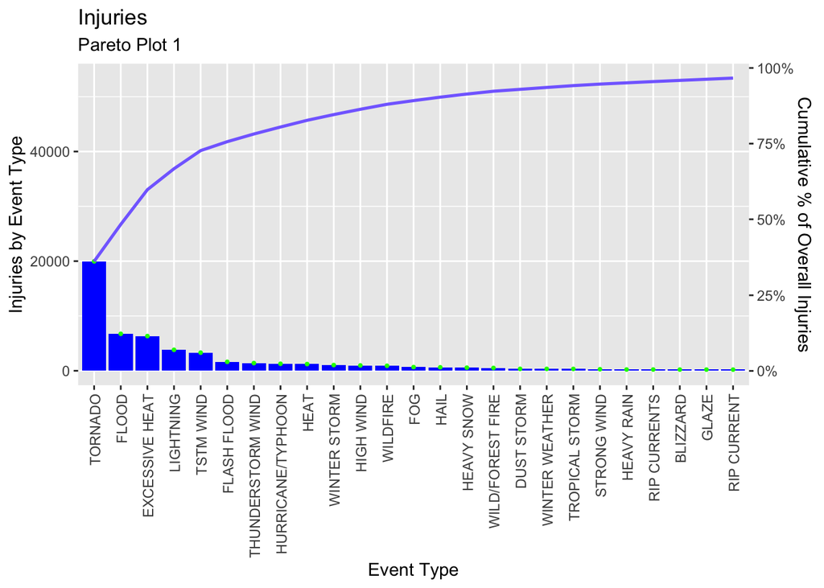

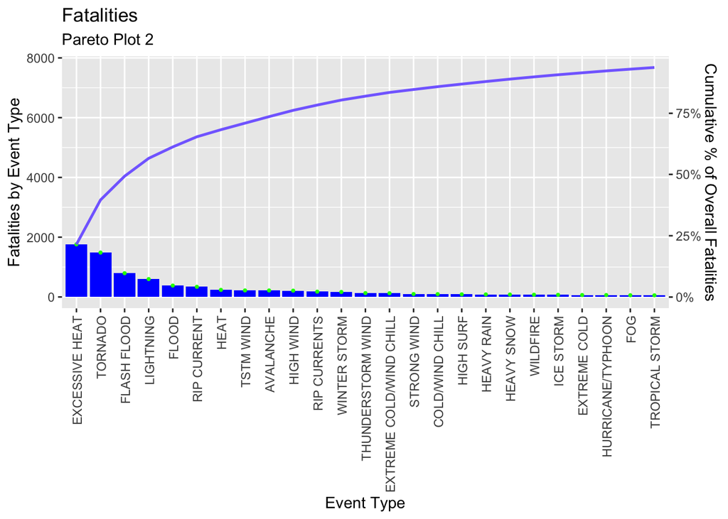

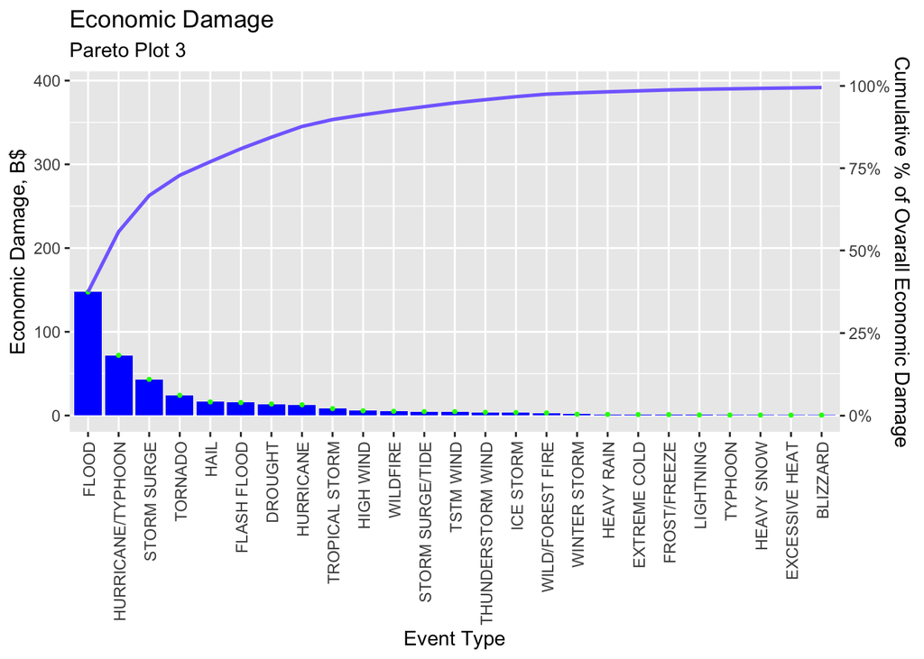